# Red Ventures Take-home Exercise

### Author: Letao (Julietta) Zhu

# Big Picture

### EDA

- Before I delve into the analysis and answer the listed question, I want to first calculate the current revenue and approval rate, creating some plots to better understand the dataset.

### Match-making Analysis

- For the first question, my first thought is to treat this as a predictive exercise. Start by building a binary classifier for approval (in general) to determine what predictors matter for determining approval. Then build separate models for approval by A, B, and C to see if the same variables seem to matter. Use random forest with feature importance.
- Part two explores what differs between lenders. Combine the feature importances analysis to determine if there are differences in who gets approved at the different lenders.
- Use separate models to predict a probability of approval for each lender for a held out test set. Then, multiply this by the revenue for each accepted loan to get an expected revenue for each customer and recommend the lender that yields the highest expected revenue. Compare this expected revenue over the set of held out customers (test data) for the "best revenue" model to current pairing.

### Comparisons and Outcomes

- I will compare the predicted revenue with Bankrate's current revenue. Hopefully the very last step of the analysis will generate a higher predicted revenue than the current one, meaning that with a better pairing model, our client can make more money.
- EDA
- Match-making Analysis
- Comparisons and Outcomes

```python
#import libraries
import numpy as np
import pandas as pd
import os
import seaborn as sns
import matplotlib.pyplot as plt
from sklearn.ensemble import RandomForestClassifier
from sklearn.model_selection import train_test_split
from sklearn.metrics import accuracy_score
%matplotlib inline
sns.set(style="whitegrid")
```

```python
os.chdir('/Users/Owner1/Desktop/rv_interivew')
```

```python
# import dataset
df = pd.read_excel("/Users/Owner1/Desktop/rv_interivew/Pre-Super_Day_candidate_dataset__28candidate_29.xlsx")
```

## EDA

```python
df['User ID'].nunique() # There are 100,000 distinct customers
```

```
100000
```

```python
# check for missing

df.isnull().sum()

# we will take out Employment_Sector due to missing values
```

```
User ID                          0
applications                     0
Reason                           0
Loan_Amount                      0
FICO_score                       0
Fico_Score_group                 0
Employment_Status                0
Employment_Sector             6407
Monthly_Gross_Income             0
Monthly_Housing_Payment          0
Ever_Bankrupt_or_Foreclose       0
Lender                           0
Approved                         0
bounty                           0
dtype: int64
```

```python
# current revenue

approval_count = df[df['Approved'] == 1].groupby('Lender').agg(
    Count_Approved=('Approved', 'count'))

current_revenue = 250*approval_count.iloc[0] + 350*approval_count.iloc[1] + 150*approval_count.iloc[2]

# Convert the Series to a scalar value for formatting
current_revenue_scalar = current_revenue.iloc[0]

# Format and print the current revenue with commas
print(f"The current revenue is: {current_revenue_scalar:,.0f}")
```

```
The current revenue is: 2,641,500
```

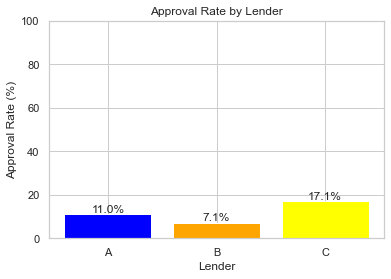

```python
import matplotlib.pyplot as plt

# Calculate the total number of applications for each lender
total_applications = df.groupby('Lender')['Approved'].count()

# Calculate the approval rate for each lender
approval_rate = approval_count['Count_Approved'] / total_applications * 100

# Plotting
fig, ax = plt.subplots()
bars = plt.bar(approval_rate.index, approval_rate, color=['blue', 'orange', 'yellow'])

# Label each bar with its exact percentage value
for bar in bars:
    yval = bar.get_height()
    plt.text(bar.get_x() + bar.get_width()/2, yval, f'{yval:.1f}%', ha='center', va='bottom')

# Set y-axis scale to be from 0 to 100
ax.set_ylim(0, 100)

plt.xlabel('Lender')
plt.ylabel('Approval Rate (%)')
plt.title('Approval Rate by Lender')
plt.show()
```

## Match-making Analysis

### Step1: Prepare the data

- Determine useless variables
- Construct new variables
- Transform categorical variables into dummies for training the model

```python
# consturct housing ratio and loan_income_ratio as new features(a form of debt to earning ratio)
df['housing_ratio'] = df['Monthly_Housing_Payment'] / df['Monthly_Gross_Income']
df['loan_income_ratio'] = df['Loan_Amount']/df['Monthly_Gross_Income']
```

```python
# dummy out categorical variables
df = pd.get_dummies(df, columns=['Reason','Fico_Score_group','Employment_Status'], drop_first=True)
```

```python
# create a feature dataset (X) and the dependent variable (y = 'Approved')

X = df.drop(['User ID','Lender','Employment_Sector','bounty','Monthly_Housing_Payment','Approved','Loan_Amount'], axis = 1)
y = df['Approved']


#split the data into training and testing sets

X_train, X_test, y_train, y_test = train_test_split(X, y, test_size=0.2, random_state=42)
```

```python
# Train the random forest model
rf_model = RandomForestClassifier(n_estimators=100, random_state=42)
rf_model.fit(X_train, y_train)

# determine the accuracy of the model
y_test_pred = rf_model.predict(X_test)

accuracy_test = accuracy_score(y_test, y_test_pred)

print("Accuracy on the test Set:", accuracy_test)
```

```
Accuracy on the test Set: 0.8901
```

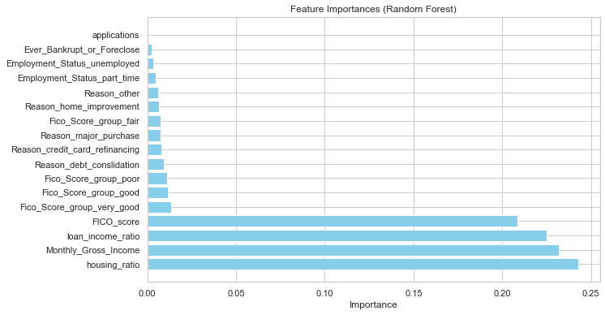

```python
# Get feature importances
feature_importances = rf_model.feature_importances_

feature_importance_df = pd.DataFrame({'Feature': X.columns, 'Importance': feature_importances})

# Sort by importances in descending order
feature_importance_df = feature_importance_df.sort_values(by='Importance', ascending=False)

plt.figure(figsize=(10, 6))
plt.barh(feature_importance_df['Feature'], feature_importance_df['Importance'], color='skyblue')
plt.xlabel('Importance')
plt.title('Feature Importances (Random Forest)')
plt.show()
```

In general across three lenders, we see that housing payment to income ratio, monthly gross income, Fico score, and loan to income ratio matter the most for determining approval.

In the following, I will look at the feature importance for each lender and see if there's any differences among them.

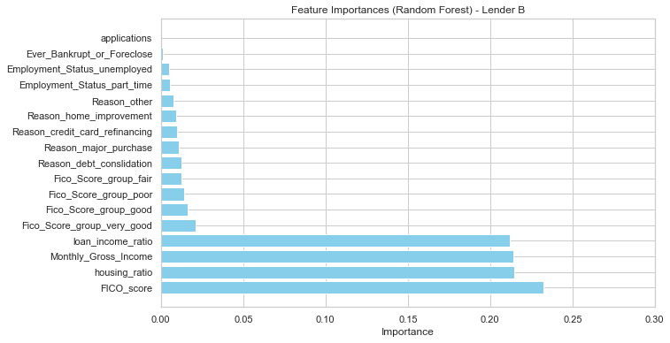

```
Accuracy for Lender B: 0.90945
```

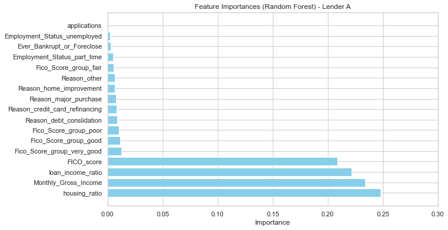

```
Accuracy for Lender A: 0.9451
```

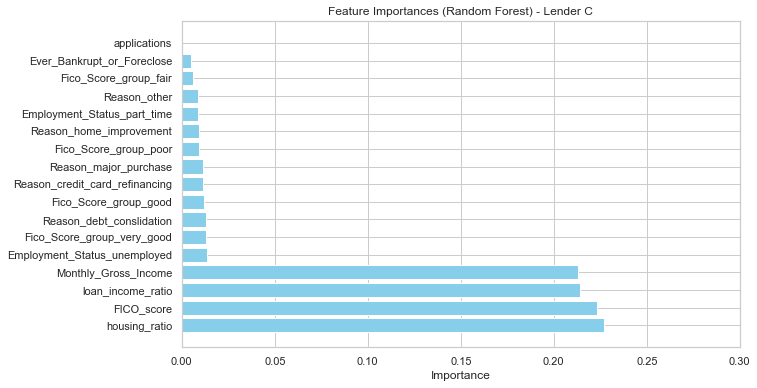

```
Accuracy for Lender C: 0.90255
```

```python
### feature importances segmented by lender ###

lenders = df['Lender'].unique()

# Set a common xlim for all plots
common_xlim = (0, 0.3)

# Loop over each lender
for lender in lenders:
    # Subset the data for the current lender
    lender_data = df[df['Lender'] == lender]

    # Create feature dataset (X) and target variable (y) for the current lender
    X_lender = lender_data.drop(['User ID','Lender','Employment_Sector', 'bounty', 'Monthly_Housing_Payment', 'Approved','Loan_Amount'], axis=1)
    y_lender = lender_data['Approved']

    # Train the random forest model
    rf_model = RandomForestClassifier(n_estimators=100, random_state=42)
    rf_model.fit(X_lender, y_lender)

    # Get feature importances
    feature_importances = rf_model.feature_importances_

    # Create a DataFrame with feature names and importances
    feature_importance_df = pd.DataFrame({'Feature': X_lender.columns, 'Importance': feature_importances})

    # Sort the DataFrame by importances in descending order
    feature_importance_df = feature_importance_df.sort_values(by='Importance', ascending=False)

    # Plotting for the current lender
    plt.figure(figsize=(10, 6))
    plt.barh(feature_importance_df['Feature'], feature_importance_df['Importance'], color='skyblue')
    plt.xlabel('Importance')
    plt.title(f'Feature Importances (Random Forest) - Lender {lender}')
    plt.xlim(common_xlim)
    plt.show()

    # Predictions on the test set
    y_pred = rf_model.predict(X_test)

    # Accuracy on the test set
    accuracy = accuracy_score(y_test, y_pred)

    # Print or use the accuracy as needed
    print(f'Accuracy for Lender {lender}: {accuracy}')
```

As you can see, FICO score, housing payment to income ratio, monthly revenue, as well as loan to income ratio remain the most important factors for all three lenders. there are slight differences in terms of the lender's priority. For example, lender B relies the most on FICO score whereas A and C rely on housing ratio.

**Note: the way we interpret feature importances is to look at the order of the features within groups. It is meaningless to, let's say, compare the importance of FICO score for lender A and B. We can only say Fico score is important relative to other features for both A and B.

With the feature importances plots, it makes sense for me to look at some descriptive statistics of the top four features across three lenders.

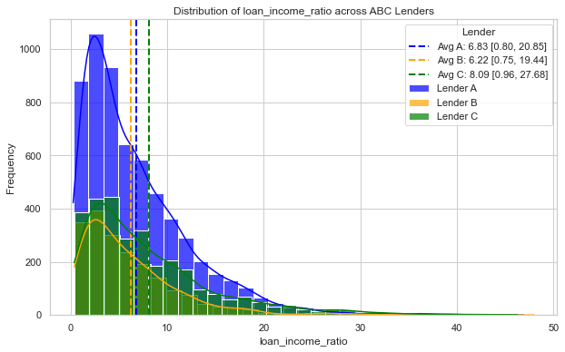

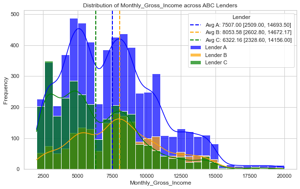

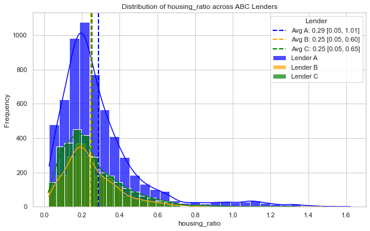

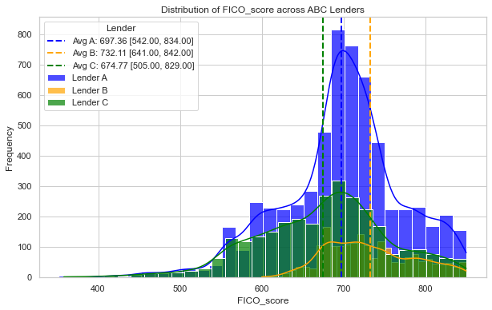

```python
top_features = ['loan_income_ratio', 'Monthly_Gross_Income', 'housing_ratio', 'FICO_score']

lender_colors = {'A': 'blue', 'B': 'orange', 'C': 'green'}



for feature in top_features:
    # Create a histogram for each feature
    plt.figure(figsize=(10, 6))
    for lender, color in lender_colors.items():
        df_approved = df[df['Approved']==1]
        lender_data = df_approved[df_approved['Lender'] == lender]
        sns.histplot(data=lender_data, x=feature, kde=True, bins=30, color=color, alpha=0.7, label=f'Lender {lender}')

        # Calculate and display the average value
        average_value = lender_data[feature].mean()

        # Calculate the 95% confidence interval
        ci_low, ci_high = sns.utils.ci(lender_data[feature])

        # Display the average value with confidence interval
        plt.axvline(average_value, color=color, linestyle='dashed', linewidth=2, label=f'Avg {lender}: {average_value:.2f} [{ci_low:.2f}, {ci_high:.2f}]')

    plt.title(f'Distribution of {feature} across ABC Lenders')
    plt.xlabel(feature)
    plt.ylabel('Frequency')
    plt.legend(title='Lender')
    plt.show()
```

```python
# Calculate the number of rows for each part
total_rows = len(df)
rows_80_percent = int(0.8 * total_rows)

#split df 80/20 manually for train and test set
df_shuffled = df.sample(frac=1, random_state=42)  # Shuffle the DataFrame
df_train = df_shuffled.iloc[:rows_80_percent, :]
df_test= df_shuffled.iloc[rows_80_percent:, :]

# Get unique lenders from the 'Lender' column
lenders = df['Lender'].unique()

df_train_by_lender = {lender: df_train[df_train['Lender'] == lender] for lender in lenders}

# Access each DataFrame by lender name
df_a = df_train_by_lender['A']
df_b = df_train_by_lender['B']
df_c = df_train_by_lender['C']


X_a = df_a.drop(['User ID','Lender','Employment_Sector','bounty','Monthly_Housing_Payment','Approved','Loan_Amount', ], axis = 1)
y_a = df_a['Approved']

X_b = df_b.drop(['User ID','Lender','Employment_Sector','bounty','Monthly_Housing_Payment','Approved','Loan_Amount'], axis = 1)
y_b = df_b['Approved']

X_c = df_c.drop(['User ID','Lender','Employment_Sector','bounty','Monthly_Housing_Payment','Approved','Loan_Amount'], axis = 1)
y_c = df_c['Approved']

# Train the random forest model
rf_model_a = RandomForestClassifier(n_estimators=100, random_state=42)
rf_model_a.fit(X_a, y_a)

rf_model_b = RandomForestClassifier(n_estimators=100, random_state=42)
rf_model_b.fit(X_b, y_b)

rf_model_c = RandomForestClassifier(n_estimators=100, random_state=42)
rf_model_c.fit(X_c, y_c)
```

```
RandomForestClassifier(random_state=42)
```

```python
X_test = df_test.drop(['User ID','Lender','Employment_Sector','bounty','Monthly_Housing_Payment','Approved','Loan_Amount'], axis = 1)
y_test = df_test['Approved']


prob_a = rf_model_a.predict_proba(X_test)[:, 1]
prob_b = rf_model_b.predict_proba(X_test)[:, 1]
prob_c = rf_model_c.predict_proba(X_test)[:, 1]

# Revenue for making a loan from lenders
revenue_a = 250
revenue_b = 350
revenue_c = 150

# Calculate expected revenue for each lender
expected_revenue_a = prob_a * revenue_a
expected_revenue_b = prob_b * revenue_b
expected_revenue_c = prob_c * revenue_c

# Determine the recommended lender for each customer
lender = np.argmax(np.column_stack((expected_revenue_a, expected_revenue_b, expected_revenue_c)), axis=1)
# Mapping function
lender_mapping = {0: 'A', 1: 'B', 2: 'C'}

# Recode recommended_lender values
recommended_lender = np.vectorize(lambda x: lender_mapping[x])(lender)

# Calculate expected revenue for the "best revenue" model
expected_revenue_best = np.max(np.column_stack((expected_revenue_a, expected_revenue_b, expected_revenue_c)), axis=1)
```

## Comparisons and Outcomes

```python
# Compare the revenue for the "best revenue" model to the other scenarios
comparison_df = pd.DataFrame({
    'Expected_Revenue_Best': expected_revenue_best,
    'Recommended_Lender': recommended_lender,
    'Expected_Revenue_Recommend_A': expected_revenue_a,
    'Probability_of_approval_A': prob_a,
    'Expected_Revenue_Recommend_B': expected_revenue_b,
    'Probability_of_approval_B': prob_b,
    'Expected_Revenue_Recommend_C': expected_revenue_c,
    'Probability_of_approval_C': prob_c})


# Print or analyze the comparison_df as needed
comparison_df.to_excel('comparison_df.xlsx', index=False)
comparison_df.head()
```

|  | Expected_Revenue_Best | Recommended_Lender | Expected_Revenue_Recommend_A | Probability_of_approval_A | Expected_Revenue_Recommend_B | Probability_of_approval_B | Expected_Revenue_Recommend_C | Probability_of_approval_C |
| --- | --- | --- | --- | --- | --- | --- | --- | --- |
| 0 | 32.5 | A | 32.5 | 0.13 | 7.0 | 0.02 | 6.0 | 0.04 |
| 1 | 25.0 | A | 25.0 | 0.10 | 0.0 | 0.00 | 18.0 | 0.12 |
| 2 | 28.0 | B | 5.0 | 0.02 | 28.0 | 0.08 | 22.5 | 0.15 |
| 3 | 19.5 | C | 10.0 | 0.04 | 0.0 | 0.00 | 19.5 | 0.13 |
| 4 | 52.5 | A | 52.5 | 0.21 | 14.0 | 0.04 | 40.5 | 0.27 |

```python
# total for the test dataset using the rf model
totals = comparison_df['Expected_Revenue_Best'].sum()


# current total for the test dataset
df_test[df_test['Approved'] == 1].groupby('Lender').agg(
    Count_Approved=('Approved', 'count'))

current_totals = 1235*250 + 390*350 + 629*150

# percentage increase
percentage_increase = (totals - current_totals)/current_totals
print(f"The percentage revenue growth will potentially be around {percentage_increase:,.2f}")



# predicted revenue
predicted_revenue = (1+percentage_increase)*current_revenue
predicted_revenue_scalar = predicted_revenue.iloc[0]
print(f"The predicted revenue with the new matching model is: {predicted_revenue_scalar:,.0f}")
```

```
The percentage revenue growth will potentially be around 0.70
The predicted revenue with the new matching model is: 4,483,836
```